## Grenouille taureau

Lithobates catesbeianus

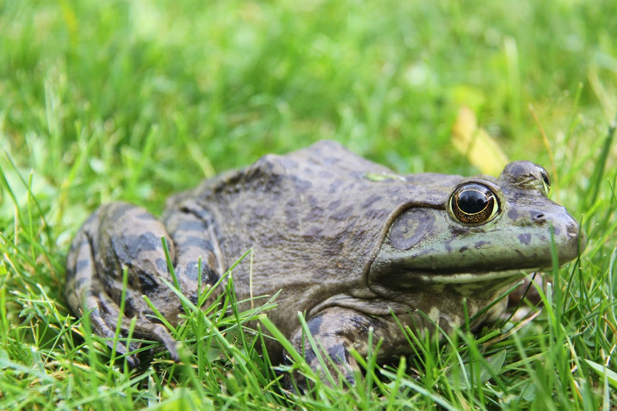

© Sander Devisscher

#### **Contexte**

La grenouille taureau (*Lithobates catesbeianus*) est l’une des plus grandes grenouilles du monde, et elle est très compétitive et vorace. Cette espèce peut être porteuse de diverses maladies et constitue une menace pour les espèces indigènes d’amphibiens ainsi que pour la biodiversité en général. En Belgique, il existe actuellement plusieurs populations de grenouilles taureau, dont la plus grande se trouve dans la vallée de la Grande Nèthe en Flandre.

#### **Liens utiles**

Pour signaler des observations de la grenouille taureau, vous pouvez vous rendre sur www.observation.org. Vos signalements sont utiles pour la surveillance et la recherche sur cette espèce.  
**Signalez une observation: [www.observation.org](https://waarnemingen.be/go/lithobates-catesbeianus/?showcase=1)**  
Vous pouvez trouver plus d’informations sur cette espèce sur la page écopédia de la grenouille taureau (notez que cette information est actuellement disponible uniquement en néerlandais).  
**Plus d’informations: [ecopedia](https://www.ecopedia.be/dieren/amerikaanse-stierkikker)**  
Le projet européen LIFE 3n-Stierkikker tente de trouver une manière durable d’arrêter la progression de cette espèce en Flandre. Le projet utilise pour cela des techniques de lutte traditionnelles en combinaison avec l’introduction de grenouilles stériles.  
**Plus d’informations sur le projet LIFE 3n-Stierkikker: [LIFE 3n-Stierkikker](https://www.natuurenbos.be/projecten/life-3n-stierkikker)**